# The Link Between Income and Region of the US

## Authors: Calvin Brauer, Jerry Hong, and Jaimes Dickerson

- Introduction
- Literature
- Data
- Plots
- Hypothesis Testing
- Conclusion

# Introduction

In 2010, approximately 1.6 million students graduated with a Bachelor's degree in the US ([source](https://educationdata.org/number-of-college-graduates)). New graduates often look for a job after college, thus entering the job market. We, as future graduates, would like to learn about where in the country is best to live if we'd like to maximize our income. We're curious if theres a link between region of the country and income.

We are looking at the average US income by region (i.e. West vs. East) in the year 2010. We live in a (somewhat) capitalist society, and thus people are generally motivated to make more money. So, as college students that will be looking to make money in the near future, we would like to explore whether there is a region in the US that makes significantly more money than the other. Obviously, this is an oversimplification and there are many other factors to evaluate when considering income. Still, we think that it would be interesting to see if there is any sort of correlation between living in a certain region and an increased income.

# Literature on the Topic

There is a significant amount of data relating to the presence of and the reasons for income inequality both locally and cross-regionally. According to Reardon and Bischoff, income inequality has a strong positive relationship with both racial and geographic segregation, meaning that areas with less diverse neighborhoods are more likely to also have more income inequality. This is relevant because of the evidence that increased income inequality is a sign of a period of significant economic growth (Kuznets).

There is also research relating to the causes of such income inequality in specific regions. Feldmann attempts to find a more general answer for this question, citing the large influence of the financial sectors of many urban areas as the reason for more wealth and opportunities than in more rural, ‘left-behind’ areas. Also, the purposeful enactment of policies which advantage the wealthier people in these urban areas at the expense of the union and blue-collar workers in regions like South Central and Southeast America have been blamed for the income disparity in different regions of the nation.

### References

Aoki, Shuhei, and Makoto Nirei. “Zipf’s Law, Pareto’s Law, and the Evolution of Top Incomes in the United States.” American Economic Journal: Macroeconomics, vol. 9, no. 3, 2017, pp. 36–71. JSTOR, http://www.jstor.org/stable/26598362. Accessed 3 Nov. 2022.

Kuznets, Simon. “Economic Growth and Income Inequality.” The American Economic Review, vol. 45, no. 1, 1955, pp. 1–28. JSTOR, http://www.jstor.org/stable/1811581. Accessed 3 Nov. 2022.

Reardon, Sean F., and Kendra Bischoff. “Income Inequality and Income Segregation.” American Journal of Sociology, vol. 116, no. 4, 2011, pp. 1092–153. JSTOR, https://doi.org/10.1086/657114. Accessed 3 Nov. 2022.

Silva, Julie A., and Robin M. Leichenko. “Regional Income Inequality and International Trade.” Economic Geography, vol. 80, no. 3, 2004, pp. 261–86. JSTOR, http://www.jstor.org/stable/30032974. Accessed 3 Nov. 2022.

Feldman, Maryann, et al. “Regional Income Disparities, Monopoly and Finance.” Cambridge Journal of Regions, Economy and Society, vol. 14, no. 1, 2020, pp. 25–49., https://doi.org/10.1093/cjres/rsaa024.

Cörvers, Frank, and Ken Mayhew. “Regional inequalities: causes and cures.” Oxford review of economic policy vol. 37,1 1-16. 5 Apr. 2021, doi:10.1093/oxrep/graa067

# The Data

## Overview

Our data source comes from the IPUMS data library. We're specifically looking at the region and income data sets, using age, sex, and race as well when dividing the data to get summary statistics. The `REGION` variable is a numerical variable that is assigned to different geographic regions across the US (ex. East, Southwest, etc.). The `INCTOT` variable is a measure of a person's total income in the year.

## Importing Necessary Libraries

```python
import os
import numpy as np
import pandas as pd
import seaborn as sns
import scipy.stats as stats
import matplotlib.pyplot as plt
from scipy.stats import ttest_ind
from statsmodels.stats.proportion import proportions_ztest
# Remove scientific notations
pd.options.display.float_format = '{:.4f}'.format
```

## Importing the Data

We'll start by importing the data.

```python
data = pd.read_csv(r"C:\Users\calvi\Google Drive\School\15th Grade\Fall 2022\ECON 220\Final Project\usa_00002.csv")
```

## Exploring the Data

Let's take a look at the basic structure of the data.

```python
data.info()
```

```
<class 'pandas.core.frame.DataFrame'>
RangeIndex: 3061692 entries, 0 to 3061691
Data columns (total 16 columns):
 #   Column    Dtype
---  ------    -----
 0   YEAR      int64
 1   SAMPLE    int64
 2   SERIAL    int64
 3   CBSERIAL  int64
 4   HHWT      float64
 5   CLUSTER   int64
 6   REGION    int64
 7   STRATA    int64
 8   GQ        int64
 9   PERNUM    int64
 10  PERWT     float64
 11  SEX       int64
 12  AGE       int64
 13  RACE      int64
 14  RACED     int64
 15  INCTOT    int64
dtypes: float64(2), int64(14)
memory usage: 373.7 MB
```

```python
data.head()
```

|  | YEAR | SAMPLE | SERIAL | CBSERIAL | HHWT | CLUSTER | REGION | STRATA | GQ | PERNUM | PERWT | SEX | AGE | RACE | RACED | INCTOT |
| --- | --- | --- | --- | --- | --- | --- | --- | --- | --- | --- | --- | --- | --- | --- | --- | --- |
| 0 | 2010 | 201001 | 1 | 69 | 96.0000 | 2010000000011 | 32 | 40001 | 1 | 1 | 96.0000 | 2 | 75 | 1 | 100 | 7500 |
| 1 | 2010 | 201001 | 2 | 80 | 97.0000 | 2010000000021 | 32 | 220001 | 1 | 1 | 97.0000 | 1 | 25 | 1 | 100 | 17000 |
| 2 | 2010 | 201001 | 2 | 80 | 97.0000 | 2010000000021 | 32 | 220001 | 1 | 2 | 128.0000 | 2 | 26 | 1 | 100 | 13000 |
| 3 | 2010 | 201001 | 2 | 80 | 97.0000 | 2010000000021 | 32 | 220001 | 1 | 3 | 182.0000 | 1 | 3 | 1 | 100 | 9999999 |
| 4 | 2010 | 201001 | 3 | 140 | 90.0000 | 2010000000031 | 32 | 10001 | 1 | 1 | 90.0000 | 2 | 87 | 1 | 100 | 29400 |

The data shows several different variables relating to income. We'll specifically be looking at total income, `INCTOT` and the region data, `REGION`.

```python
# reducing the data down to just the variables that we want
del data['YEAR']
del data['SAMPLE']
del data['SERIAL']
del data['CBSERIAL']
del data['HHWT']
del data['CLUSTER']
del data['STRATA']
del data['GQ']
del data['PERNUM']
del data['PERWT']
data.head()
```

|  | REGION | SEX | AGE | RACE | RACED | INCTOT |
| --- | --- | --- | --- | --- | --- | --- |
| 0 | 32 | 2 | 75 | 1 | 100 | 7500 |
| 1 | 32 | 1 | 25 | 1 | 100 | 17000 |
| 2 | 32 | 2 | 26 | 1 | 100 | 13000 |
| 3 | 32 | 1 | 3 | 1 | 100 | 9999999 |
| 4 | 32 | 2 | 87 | 1 | 100 | 29400 |

```python
# assigning inEast to True if the region is in the east, False if it's in the west
data['inEast'] = (data['REGION'] == 11) | (data['REGION'] == 12) | (data['REGION'] == 21) | (data['REGION'] == 31) | (data['REGION'] == 32)
data.head()
```

|  | REGION | SEX | AGE | RACE | RACED | INCTOT | inEast |
| --- | --- | --- | --- | --- | --- | --- | --- |
| 0 | 32 | 2 | 75 | 1 | 100 | 7500 | True |
| 1 | 32 | 1 | 25 | 1 | 100 | 17000 | True |
| 2 | 32 | 2 | 26 | 1 | 100 | 13000 | True |
| 3 | 32 | 1 | 3 | 1 | 100 | 9999999 | True |
| 4 | 32 | 2 | 87 | 1 | 100 | 29400 | True |

## Data Cleaning

When `INCTOT` is 9999999, it is a placeholder for NA. Thus, we'll remove these observations from our data.

```python
strange = data[data['INCTOT'] == 9999999]
data['INCTOT'] = data['INCTOT'].drop(strange.index)
```

## Creating Dummy Variables

We need to create dummy variables for sex and race in order to do our summary statistics

```python
## Variable: SEX
# create a "female" variable
data['female'] = data['SEX']==2

## Variable: RACE
# creating 3 different dummies: white, black, and other
data['raceWhite'] = data['RACE'] == 1
data['raceBlack'] = data['RACE'] == 2
data['raceOther'] = data['RACE'] > 2
```

## Summary Statistics

```python
# getting mean, standard deviation, min, max, and count of income, region, sex, age, and race
data[['INCTOT', 'inEast', 'female', 'AGE', 'raceWhite', 'raceBlack', 'raceOther']].agg(['mean', 'std', 'min', 'max', 'count'])
```

|  | INCTOT | inEast | female | AGE | raceWhite | raceBlack | raceOther |
| --- | --- | --- | --- | --- | --- | --- | --- |
| mean | 33779.0090 | 0.5861 | 0.5137 | 39.6948 | 0.7766 | 0.1042 | 0.1192 |
| std | 47945.2973 | 0.4925 | 0.4998 | 23.3445 | 0.4165 | 0.3055 | 0.3241 |
| min | -15870.0000 | False | False | 0.0000 | False | False | False |
| max | 1207000.0000 | True | True | 95.0000 | True | True | True |
| count | 2494822.0000 | 3061692 | 3061692 | 3061692.0000 | 3061692 | 3061692 | 3061692 |

# Plots

Let's make two plots of the data. The first will be a bar plot of mean income by region, and the second will be a heatmap of mean income by sex and race.

[figure not shown]

```python
bar = sns.barplot(data = data, x = 'inEast', y = 'INCTOT', ci=None)
bar.set(title='Mean Income by Region', xlabel = 'Region', ylabel = 'Income', xticklabels = ['East', 'West']);
```

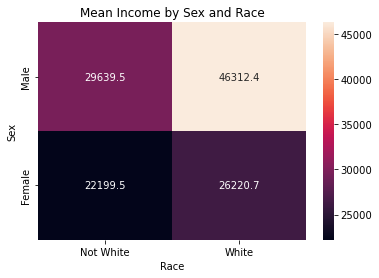

```python
pivot = data.pivot_table(values='INCTOT',
                        index='female',
                        columns = 'raceWhite',
                        aggfunc='mean')
heatmap = sns.heatmap(pivot, annot=True, fmt='g')
heatmap.set(title="Mean Income by Sex and Race", xlabel='Race', ylabel='Sex',
            xticklabels=['Not White', 'White'], yticklabels=['Male', 'Female']);
```

Our first plot appears to show that there is a minimal difference between income in the east and west. However, it appears that sex and race *do* make a difference in income on average, which may mean that these variables are better at explaining inequalities in income (though they're much more out of our control as college students).

# Hypothesis Testing

For all of our hypothesis testing, we'll set $\alpha=0.5$.

## Test 1: Difference in means of income across regions

Null Hypothesis ($H_0$): There is no significant difference in means of income between East and West regions of the U.S.

Alternative Hypothesis ($H_A$): There is a significant difference in means of income between East and West regions of the U.S.

```python
east = data[data['inEast']]['INCTOT'].dropna()
west = data[~data['inEast']]['INCTOT'].dropna()
ttest_ind(east, west)
```

```
Ttest_indResult(statistic=11.260177822227343, pvalue=2.0667982405639064e-29)
```

Because our p-value is less than $\alpha$, we reject $H_0$ and conclude that there is a significant difference in means between the East and West.

## Test 2: Difference in means of income across race

Null Hypothesis ($H_0$): There is no significant difference in means of income between people who are white and not white.

Alternative Hypothesis ($H_A$): There is a significant difference in means of income between people who are white and not white.

```python
white = data[data['raceWhite']]['INCTOT'].dropna()
nonWhite = data[~data['raceWhite']]['INCTOT'].dropna()
ttest_ind(white, nonWhite)
```

```
Ttest_indResult(statistic=137.38868128152953, pvalue=0.0)
```

Because our p-value is less than $\alpha$, we reject $H_0$ and conclude that there is a significant difference in means between people who are white and not white.

## Test 3: Difference in means of income across sex

Null Hypothesis ($H_0$): There is no significant difference in means of income between people who are female and male.

Alternative Hypothesis ($H_A$): There is a significant difference in means of income between people who are female and male.

```python
female = data[data['female']]['INCTOT'].dropna()
male = data[~data['female']]['INCTOT'].dropna()
ttest_ind(female, male)
```

```
Ttest_indResult(statistic=-293.17318792296476, pvalue=0.0)
```

Because our p-value is less than $\alpha$, we reject $H_0$ and conclude that there is a significant difference in means between people who are female and male.

# Conclusion

From the hypothesis tests conducted, we see there is sufficient evidence that shows there is a significant difference in means of income between the East and West regions of the United States. We also determine that there are significant differences in means of income among race and gender. This confirms our speculation that income inequality, whether it is by region, race, or gender, has existed at least in the United States. One question we have for further is determining the effect these differences have on the regions. Do they pose a significant influence in the difference in incomes between regions?

```python
!jupyter nbconvert --to html Final_Project.ipynb
```